# Project: Investigating a medical appointments dataset

## Exploratory Data Analysis

```python
#Let's group age and see if it is related directly with missing the appointments
df['life_period'] = pd.cut(x=df['Age'], bins=[0, 35, 60, 105], labels=['young', 'mid-life', 'old'])
df
```

|  | PatientId | AppointmentID | Gender | ScheduledDay | AppointmentDay | Age | Neighbourhood | Scholarship | Hypertension | Diabetes | Alcoholism | Handicap | SMS_received | Noshow | ScheduledHour | ScheduledDayOfWeek | life_period |
| --- | --- | --- | --- | --- | --- | --- | --- | --- | --- | --- | --- | --- | --- | --- | --- | --- | --- |
| 0 | 2.987250e+13 | 5642903 | F | 2016-04-29 18:38:08 | 2016-04-29 | 62 | JARDIM DA PENHA | 0 | 1 | 0 | 0 | 0 | 0 | No | 18 | 4 | old |
| 1 | 5.589978e+14 | 5642503 | M | 2016-04-29 16:08:27 | 2016-04-29 | 56 | JARDIM DA PENHA | 0 | 0 | 0 | 0 | 0 | 0 | No | 16 | 4 | mid-life |
| 2 | 4.262962e+12 | 5642549 | F | 2016-04-29 16:19:04 | 2016-04-29 | 62 | MATA DA PRAIA | 0 | 0 | 0 | 0 | 0 | 0 | No | 16 | 4 | old |
| 3 | 8.679512e+11 | 5642828 | F | 2016-04-29 17:29:31 | 2016-04-29 | 8 | PONTAL DE CAMBURI | 0 | 0 | 0 | 0 | 0 | 0 | No | 17 | 4 | young |
| 4 | 8.841186e+12 | 5642494 | F | 2016-04-29 16:07:23 | 2016-04-29 | 56 | JARDIM DA PENHA | 0 | 1 | 1 | 0 | 0 | 0 | No | 16 | 4 | mid-life |
| ... | ... | ... | ... | ... | ... | ... | ... | ... | ... | ... | ... | ... | ... | ... | ... | ... | ... |
| 110522 | 2.572134e+12 | 5651768 | F | 2016-05-03 09:15:35 | 2016-06-07 | 56 | MARIA ORTIZ | 0 | 0 | 0 | 0 | 0 | 1 | No | 9 | 1 | mid-life |
| 110523 | 3.596266e+12 | 5650093 | F | 2016-05-03 07:27:33 | 2016-06-07 | 51 | MARIA ORTIZ | 0 | 0 | 0 | 0 | 0 | 1 | No | 7 | 1 | mid-life |
| 110524 | 1.557663e+13 | 5630692 | F | 2016-04-27 16:03:52 | 2016-06-07 | 21 | MARIA ORTIZ | 0 | 0 | 0 | 0 | 0 | 1 | No | 16 | 2 | young |
| 110525 | 9.213493e+13 | 5630323 | F | 2016-04-27 15:09:23 | 2016-06-07 | 38 | MARIA ORTIZ | 0 | 0 | 0 | 0 | 0 | 1 | No | 15 | 2 | mid-life |
| 110526 | 3.775115e+14 | 5629448 | F | 2016-04-27 13:30:56 | 2016-06-07 | 54 | MARIA ORTIZ | 0 | 0 | 0 | 0 | 0 | 1 | No | 13 | 2 | mid-life |

110521 rows × 17 columns

```python
#We have to replace Yes and No with 0 and 1 in order to perform the analysis
df.Noshow.replace(['Yes', 'No'], [1, 0], inplace=True)
df
```

|  | PatientId | AppointmentID | Gender | ScheduledDay | AppointmentDay | Age | Neighbourhood | Scholarship | Hypertension | Diabetes | Alcoholism | Handicap | SMS_received | Noshow | ScheduledHour | ScheduledDayOfWeek | life_period |
| --- | --- | --- | --- | --- | --- | --- | --- | --- | --- | --- | --- | --- | --- | --- | --- | --- | --- |
| 0 | 2.987250e+13 | 5642903 | F | 2016-04-29 18:38:08 | 2016-04-29 | 62 | JARDIM DA PENHA | 0 | 1 | 0 | 0 | 0 | 0 | 0 | 18 | 4 | old |
| 1 | 5.589978e+14 | 5642503 | M | 2016-04-29 16:08:27 | 2016-04-29 | 56 | JARDIM DA PENHA | 0 | 0 | 0 | 0 | 0 | 0 | 0 | 16 | 4 | mid-life |
| 2 | 4.262962e+12 | 5642549 | F | 2016-04-29 16:19:04 | 2016-04-29 | 62 | MATA DA PRAIA | 0 | 0 | 0 | 0 | 0 | 0 | 0 | 16 | 4 | old |
| 3 | 8.679512e+11 | 5642828 | F | 2016-04-29 17:29:31 | 2016-04-29 | 8 | PONTAL DE CAMBURI | 0 | 0 | 0 | 0 | 0 | 0 | 0 | 17 | 4 | young |
| 4 | 8.841186e+12 | 5642494 | F | 2016-04-29 16:07:23 | 2016-04-29 | 56 | JARDIM DA PENHA | 0 | 1 | 1 | 0 | 0 | 0 | 0 | 16 | 4 | mid-life |
| ... | ... | ... | ... | ... | ... | ... | ... | ... | ... | ... | ... | ... | ... | ... | ... | ... | ... |
| 110522 | 2.572134e+12 | 5651768 | F | 2016-05-03 09:15:35 | 2016-06-07 | 56 | MARIA ORTIZ | 0 | 0 | 0 | 0 | 0 | 1 | 0 | 9 | 1 | mid-life |
| 110523 | 3.596266e+12 | 5650093 | F | 2016-05-03 07:27:33 | 2016-06-07 | 51 | MARIA ORTIZ | 0 | 0 | 0 | 0 | 0 | 1 | 0 | 7 | 1 | mid-life |
| 110524 | 1.557663e+13 | 5630692 | F | 2016-04-27 16:03:52 | 2016-06-07 | 21 | MARIA ORTIZ | 0 | 0 | 0 | 0 | 0 | 1 | 0 | 16 | 2 | young |
| 110525 | 9.213493e+13 | 5630323 | F | 2016-04-27 15:09:23 | 2016-06-07 | 38 | MARIA ORTIZ | 0 | 0 | 0 | 0 | 0 | 1 | 0 | 15 | 2 | mid-life |
| 110526 | 3.775115e+14 | 5629448 | F | 2016-04-27 13:30:56 | 2016-06-07 | 54 | MARIA ORTIZ | 0 | 0 | 0 | 0 | 0 | 1 | 0 | 13 | 2 | mid-life |

110521 rows × 17 columns

```python
#Changing the type of data in order to perform the analysis
df["Gender"] = df["Gender"].astype("category")
```

```python
df["Neighbourhood"] = df["Neighbourhood"].astype("category")
```

```python
df["life_period"] = df["life_period"].astype("category")
```

```python
#We can make the best relation if we transform age into 0 and 1 values based on the previously made age categories
pd.get_dummies(df['life_period'], prefix='life_period')
```

|  | life_period_young | life_period_mid-life | life_period_old |
| --- | --- | --- | --- |
| 0 | 0 | 0 | 1 |
| 1 | 0 | 1 | 0 |
| 2 | 0 | 0 | 1 |
| 3 | 1 | 0 | 0 |
| 4 | 0 | 1 | 0 |
| ... | ... | ... | ... |
| 110522 | 0 | 1 | 0 |
| 110523 | 0 | 1 | 0 |
| 110524 | 1 | 0 | 0 |
| 110525 | 0 | 1 | 0 |
| 110526 | 0 | 1 | 0 |

110521 rows × 3 columns

```python
df = pd.concat([df, pd.get_dummies(df["life_period"], prefix='life_period')], axis=1)
df.head(5)
```

|  | PatientId | AppointmentID | Gender | ScheduledDay | AppointmentDay | Age | Neighbourhood | Scholarship | Hypertension | Diabetes | Alcoholism | Handicap | SMS_received | Noshow | ScheduledHour | ScheduledDayOfWeek | life_period | life_period_young | life_period_mid-life | life_period_old |
| --- | --- | --- | --- | --- | --- | --- | --- | --- | --- | --- | --- | --- | --- | --- | --- | --- | --- | --- | --- | --- |
| 0 | 2.987250e+13 | 5642903 | F | 2016-04-29 18:38:08 | 2016-04-29 | 62 | JARDIM DA PENHA | 0 | 1 | 0 | 0 | 0 | 0 | 0 | 18 | 4 | old | 0 | 0 | 1 |
| 1 | 5.589978e+14 | 5642503 | M | 2016-04-29 16:08:27 | 2016-04-29 | 56 | JARDIM DA PENHA | 0 | 0 | 0 | 0 | 0 | 0 | 0 | 16 | 4 | mid-life | 0 | 1 | 0 |
| 2 | 4.262962e+12 | 5642549 | F | 2016-04-29 16:19:04 | 2016-04-29 | 62 | MATA DA PRAIA | 0 | 0 | 0 | 0 | 0 | 0 | 0 | 16 | 4 | old | 0 | 0 | 1 |
| 3 | 8.679512e+11 | 5642828 | F | 2016-04-29 17:29:31 | 2016-04-29 | 8 | PONTAL DE CAMBURI | 0 | 0 | 0 | 0 | 0 | 0 | 0 | 17 | 4 | young | 1 | 0 | 0 |
| 4 | 8.841186e+12 | 5642494 | F | 2016-04-29 16:07:23 | 2016-04-29 | 56 | JARDIM DA PENHA | 0 | 1 | 1 | 0 | 0 | 0 | 0 | 16 | 4 | mid-life | 0 | 1 | 0 |

```python
df = df.drop(columns=["life_period"])
df.head(5)
```

|  | PatientId | AppointmentID | Gender | ScheduledDay | AppointmentDay | Age | Neighbourhood | Scholarship | Hypertension | Diabetes | Alcoholism | Handicap | SMS_received | Noshow | ScheduledHour | ScheduledDayOfWeek | life_period_young | life_period_mid-life | life_period_old |
| --- | --- | --- | --- | --- | --- | --- | --- | --- | --- | --- | --- | --- | --- | --- | --- | --- | --- | --- | --- |
| 0 | 2.987250e+13 | 5642903 | F | 2016-04-29 18:38:08 | 2016-04-29 | 62 | JARDIM DA PENHA | 0 | 1 | 0 | 0 | 0 | 0 | 0 | 18 | 4 | 0 | 0 | 1 |
| 1 | 5.589978e+14 | 5642503 | M | 2016-04-29 16:08:27 | 2016-04-29 | 56 | JARDIM DA PENHA | 0 | 0 | 0 | 0 | 0 | 0 | 0 | 16 | 4 | 0 | 1 | 0 |
| 2 | 4.262962e+12 | 5642549 | F | 2016-04-29 16:19:04 | 2016-04-29 | 62 | MATA DA PRAIA | 0 | 0 | 0 | 0 | 0 | 0 | 0 | 16 | 4 | 0 | 0 | 1 |
| 3 | 8.679512e+11 | 5642828 | F | 2016-04-29 17:29:31 | 2016-04-29 | 8 | PONTAL DE CAMBURI | 0 | 0 | 0 | 0 | 0 | 0 | 0 | 17 | 4 | 1 | 0 | 0 |
| 4 | 8.841186e+12 | 5642494 | F | 2016-04-29 16:07:23 | 2016-04-29 | 56 | JARDIM DA PENHA | 0 | 1 | 1 | 0 | 0 | 0 | 0 | 16 | 4 | 0 | 1 | 0 |

```python
df = df.dropna(axis = 0, how='any')
```

```python
#We will apply the same method on gender
pd.get_dummies(df['Gender'], prefix='Gender')
```

|  | Gender_F | Gender_M |
| --- | --- | --- |
| 0 | 1 | 0 |
| 1 | 0 | 1 |
| 2 | 1 | 0 |
| 3 | 1 | 0 |
| 4 | 1 | 0 |
| ... | ... | ... |
| 110522 | 1 | 0 |
| 110523 | 1 | 0 |
| 110524 | 1 | 0 |
| 110525 | 1 | 0 |
| 110526 | 1 | 0 |

110521 rows × 2 columns

```python
df = pd.concat([df, pd.get_dummies(df["Gender"], prefix='Gender')], axis=1)
df.head(5)
```

|  | PatientId | AppointmentID | Gender | ScheduledDay | AppointmentDay | Age | Neighbourhood | Scholarship | Hypertension | Diabetes | ... | Handicap | SMS_received | Noshow | ScheduledHour | ScheduledDayOfWeek | life_period_young | life_period_mid-life | life_period_old | Gender_F | Gender_M |
| --- | --- | --- | --- | --- | --- | --- | --- | --- | --- | --- | --- | --- | --- | --- | --- | --- | --- | --- | --- | --- | --- |
| 0 | 2.987250e+13 | 5642903 | F | 2016-04-29 18:38:08 | 2016-04-29 | 62 | JARDIM DA PENHA | 0 | 1 | 0 | ... | 0 | 0 | 0 | 18 | 4 | 0 | 0 | 1 | 1 | 0 |
| 1 | 5.589978e+14 | 5642503 | M | 2016-04-29 16:08:27 | 2016-04-29 | 56 | JARDIM DA PENHA | 0 | 0 | 0 | ... | 0 | 0 | 0 | 16 | 4 | 0 | 1 | 0 | 0 | 1 |
| 2 | 4.262962e+12 | 5642549 | F | 2016-04-29 16:19:04 | 2016-04-29 | 62 | MATA DA PRAIA | 0 | 0 | 0 | ... | 0 | 0 | 0 | 16 | 4 | 0 | 0 | 1 | 1 | 0 |
| 3 | 8.679512e+11 | 5642828 | F | 2016-04-29 17:29:31 | 2016-04-29 | 8 | PONTAL DE CAMBURI | 0 | 0 | 0 | ... | 0 | 0 | 0 | 17 | 4 | 1 | 0 | 0 | 1 | 0 |
| 4 | 8.841186e+12 | 5642494 | F | 2016-04-29 16:07:23 | 2016-04-29 | 56 | JARDIM DA PENHA | 0 | 1 | 1 | ... | 0 | 0 | 0 | 16 | 4 | 0 | 1 | 0 | 1 | 0 |

5 rows × 21 columns

```python
df.dtypes
```

```
PatientId                      float64
AppointmentID                    int64
Gender                        category
ScheduledDay            datetime64[ns]
AppointmentDay          datetime64[ns]
Age                              int64
Neighbourhood                 category
Scholarship                      int64
Hypertension                     int64
Diabetes                         int64
Alcoholism                       int64
Handicap                         int64
SMS_received                     int64
Noshow                           int64
ScheduledHour                    int64
ScheduledDayOfWeek               int64
life_period_young                uint8
life_period_mid-life             uint8
life_period_old                  uint8
Gender_F                         uint8
Gender_M                         uint8
dtype: object
```

```python
#Dataframe description
df.describe()
```

|  | PatientId | AppointmentID | Age | Scholarship | Hypertension | Diabetes | Alcoholism | Handicap | SMS_received | Noshow | ScheduledHour | ScheduledDayOfWeek | life_period_young | life_period_mid-life | life_period_old | Gender_F | Gender_M |
| --- | --- | --- | --- | --- | --- | --- | --- | --- | --- | --- | --- | --- | --- | --- | --- | --- | --- |
| count | 1.105210e+05 | 1.105210e+05 | 110521.000000 | 110521.000000 | 110521.000000 | 110521.000000 | 110521.000000 | 110521.000000 | 110521.000000 | 110521.000000 | 110521.000000 | 110521.000000 | 110521.000000 | 110521.000000 | 110521.000000 | 110521.000000 | 110521.000000 |
| mean | 1.474921e+14 | 5.675304e+06 | 37.085694 | 0.098271 | 0.197248 | 0.071869 | 0.030401 | 0.022213 | 0.321034 | 0.201916 | 10.774595 | 1.851992 | 0.447553 | 0.341664 | 0.178762 | 0.649958 | 0.350042 |
| std | 2.560928e+14 | 7.129576e+04 | 23.104606 | 0.297682 | 0.397923 | 0.258272 | 0.171690 | 0.161440 | 0.466876 | 0.401432 | 3.216217 | 1.378493 | 0.497244 | 0.474270 | 0.383155 | 0.476985 | 0.476985 |
| min | 3.921784e+04 | 5.030230e+06 | 0.000000 | 0.000000 | 0.000000 | 0.000000 | 0.000000 | 0.000000 | 0.000000 | 0.000000 | 6.000000 | 0.000000 | 0.000000 | 0.000000 | 0.000000 | 0.000000 | 0.000000 |
| 25% | 4.172457e+12 | 5.640285e+06 | 18.000000 | 0.000000 | 0.000000 | 0.000000 | 0.000000 | 0.000000 | 0.000000 | 0.000000 | 8.000000 | 1.000000 | 0.000000 | 0.000000 | 0.000000 | 0.000000 | 0.000000 |
| 50% | 3.172598e+13 | 5.680569e+06 | 37.000000 | 0.000000 | 0.000000 | 0.000000 | 0.000000 | 0.000000 | 0.000000 | 0.000000 | 10.000000 | 2.000000 | 0.000000 | 0.000000 | 0.000000 | 1.000000 | 0.000000 |
| 75% | 9.438963e+13 | 5.725523e+06 | 55.000000 | 0.000000 | 0.000000 | 0.000000 | 0.000000 | 0.000000 | 1.000000 | 0.000000 | 13.000000 | 3.000000 | 1.000000 | 1.000000 | 0.000000 | 1.000000 | 1.000000 |
| max | 9.999816e+14 | 5.790484e+06 | 102.000000 | 1.000000 | 1.000000 | 1.000000 | 1.000000 | 4.000000 | 1.000000 | 1.000000 | 21.000000 | 5.000000 | 1.000000 | 1.000000 | 1.000000 | 1.000000 | 1.000000 |

```python
df.head(5)
```

|  | PatientId | AppointmentID | Gender | ScheduledDay | AppointmentDay | Age | Neighbourhood | Scholarship | Hypertension | Diabetes | ... | Handicap | SMS_received | Noshow | ScheduledHour | ScheduledDayOfWeek | life_period_young | life_period_mid-life | life_period_old | Gender_F | Gender_M |
| --- | --- | --- | --- | --- | --- | --- | --- | --- | --- | --- | --- | --- | --- | --- | --- | --- | --- | --- | --- | --- | --- |
| 0 | 2.987250e+13 | 5642903 | F | 2016-04-29 18:38:08 | 2016-04-29 | 62 | JARDIM DA PENHA | 0 | 1 | 0 | ... | 0 | 0 | 0 | 18 | 4 | 0 | 0 | 1 | 1 | 0 |
| 1 | 5.589978e+14 | 5642503 | M | 2016-04-29 16:08:27 | 2016-04-29 | 56 | JARDIM DA PENHA | 0 | 0 | 0 | ... | 0 | 0 | 0 | 16 | 4 | 0 | 1 | 0 | 0 | 1 |
| 2 | 4.262962e+12 | 5642549 | F | 2016-04-29 16:19:04 | 2016-04-29 | 62 | MATA DA PRAIA | 0 | 0 | 0 | ... | 0 | 0 | 0 | 16 | 4 | 0 | 0 | 1 | 1 | 0 |
| 3 | 8.679512e+11 | 5642828 | F | 2016-04-29 17:29:31 | 2016-04-29 | 8 | PONTAL DE CAMBURI | 0 | 0 | 0 | ... | 0 | 0 | 0 | 17 | 4 | 1 | 0 | 0 | 1 | 0 |
| 4 | 8.841186e+12 | 5642494 | F | 2016-04-29 16:07:23 | 2016-04-29 | 56 | JARDIM DA PENHA | 0 | 1 | 1 | ... | 0 | 0 | 0 | 16 | 4 | 0 | 1 | 0 | 1 | 0 |

5 rows × 21 columns

### Which variables are correlated with No-show and how?

```python
#corr = df.corr()
```

```python
#sns.heatmap(corr)
```

##### Creating a correlation heatmap of all variables in order to see how they are correlated to No-show and each other

```python
corr = df.corr(method="spearman")
```

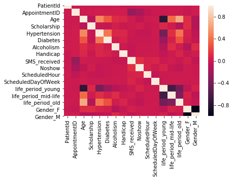

```python
sns.heatmap(corr)
```

```python
corr_Noshow = corr["Noshow"]
```

```python
print(corr["Noshow"])
```

```
PatientId              -0.000699
AppointmentID          -0.171727
Age                    -0.061322
Scholarship             0.029150
Hypertension           -0.035673
Diabetes               -0.015170
Alcoholism             -0.000189
Handicap               -0.007616
SMS_received            0.126478
Noshow                  1.000000
ScheduledHour           0.065074
ScheduledDayOfWeek      0.006077
life_period_young       0.066788
life_period_mid-life   -0.019560
life_period_old        -0.058018
Gender_F                0.004089
Gender_M               -0.004089
Name: Noshow, dtype: float64
```

#### Plotting histograms for columns correlated with No-show

```python
df[df['Noshow']==1]['SMS_received'].value_counts()
```

```
0    12532
1     9784
Name: SMS_received, dtype: int64
```

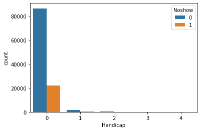

```python
sns.countplot(data=df, x="Handicap", hue="Noshow")
```

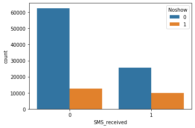

```python
sns.countplot(data=df, x="SMS_received", hue="Noshow")
```

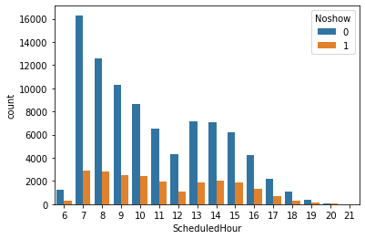

```python
sns.countplot(data=df, x="ScheduledHour", hue="Noshow")
```

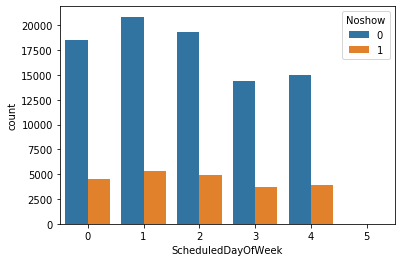

```python
sns.countplot(data=df, x="ScheduledDayOfWeek", hue="Noshow")
```

### How does the life period of patients affect their appointment attendance?

```python
df[df['Gender_F']==1]['Noshow'].value_counts()
```

```
0    57243
1    14591
Name: Noshow, dtype: int64
```

```python
df[df['Gender_M']==1]['Noshow'].value_counts()
```

```
0    30962
1     7725
Name: Noshow, dtype: int64
```

```python
df[df['Noshow']==1]['life_period_old'].value_counts()
```

```
0    19313
1     3003
Name: life_period_old, dtype: int64
```

```python
df[df['life_period_young']==1]['Noshow'].value_counts()
```

```
0    38003
1    11461
Name: Noshow, dtype: int64
```

```python
df[df['life_period_mid-life']==1]['Noshow'].value_counts()
```

```
0    30548
1     7213
Name: Noshow, dtype: int64
```

```python
df[df['life_period_old']==1]['Noshow'].value_counts()
```

```
0    16754
1     3003
Name: Noshow, dtype: int64
```

### **Conclusion**

The data is imbalanced. The only variables correlated to No-show column (patient showing up for the appointment or skipping it) were SMS_received and Appointment_ID. Approximately the same ratio of male and female patients shows up for their appointments. When it comes to life period, we can conclude that young people tend to miss their appointments the most, then mid-life, and old people are the most responsible, given from ratio of showing up and not showing up for all three categories. I have to accentuate that the difference is not significant, only noticable. We can also tell that most of the appointments is in the morning, and the least in the evening (which was expected). When it comes to diseases, we can conclude from the heatmap that Age is directly correlated with Diabetes and Hypetension.